# Question 4

2025-11-28

## Introduction

Understanding how the public evaluates government performance is essential in shaping policy decisions, especially when it comes to issues of crime and safety. Public trust in government institutions often influences opinions about which areas require more funding, and crime-prevention efforts are among the most politically visible and publicly debated domains. Our central question asks whether trust in institutions such as the executive branch, Congress, financial institutions, and major companies is associated with people’s willingness to support additional government spending on halting rising crime rates. We also extend this question to examine whether public attitudes are aligned with actual national crime trends: when violent crime increases, does public demand for crime-prevention funding rise as well, or do these attitudes move independently of real-world conditions? By exploring these relationships, our goal is to better understand how public opinion, institutional trust, and objective crime statistics interact.

## About the Data

### General Social Survey (GSS)

We began by downloading the full GSS dataset and selecting only the variables relevant to answering our research question. These included natcrime, which captures public opinion on whether the government spends “too little,” “about right,” or “too much” on crime prevention, along with a series of trust variables measuring confidence in the executive branch (confed), Congress (conlegis), financial institutions (confinan), and major companies (conbus).

Because the GSS uses many special codes such as “Inapplicable,” “Don’t know,” and “No answer,” our first step was to clean these values. Instead of deleting rows—which could cause unnecessary data loss—we converted all non-valid codes into NA. This preserved the structure of the dataset while ensuring that only meaningful responses were used in statistical analysis.

#### R Code: Importing and Cleaning GSS Data

```r
library(dplyr)
library(stringr)
library(tidyverse)
```

```r
library(ggplot2)
library(vcd)
library(patchwork)
library(lubridate)
library(tidyr)
library(car)
library(FSA)
GSS <- read.csv("Data/GSS.csv")


# Make every column character so we can filter reliably
GSS <- GSS %>% mutate(across(everything(), as.character))

GSS_clean <- GSS %>%

  # Race: keep only White, Black, Other
  mutate(race = ifelse(race %in% c("White", "Black", "Other"), race, NA)) %>%

  # Income: turn missing codes into NA
  mutate(income = ifelse(income %in% c(".i:  Inapplicable",
                                       ".d:  Do not Know/Cannot Choose",
                                       ".r:  Refused",
                                       ".n:  No answer",
                                       ".s:  Skipped on Web"),
                         NA, income)) %>%

  # Happy: keep only 3 valid levels, others to NA
  mutate(happy = ifelse(happy %in% c("Not too happy", "Pretty happy", "Very happy"),
                        happy, NA)) %>%

  # Confidence variables (each keeps only 3 valid responses)
  mutate(confinan  = ifelse(confinan  %in% c("A GREAT DEAL", "ONLY SOME", "HARDLY ANY"), confinan,  NA),
         conbus    = ifelse(conbus    %in% c("A GREAT DEAL", "ONLY SOME", "HARDLY ANY"), conbus,    NA),
         confed    = ifelse(confed    %in% c("A GREAT DEAL", "ONLY SOME", "HARDLY ANY"), confed,    NA),
         conlegis  = ifelse(conlegis  %in% c("A GREAT DEAL", "ONLY SOME", "HARDLY ANY"), conlegis,  NA)) %>%

  # Satisfaction with finances
  mutate(satfin = ifelse(satfin %in% c("Not satisfied at all",
                                       "More or less satisfied",
                                       "Pretty well satisfied"),
                         satfin, NA)) %>%

  # Financial alternatives
  mutate(finalter = ifelse(finalter %in% c("Better", "Stayed same", "Worse"),
                           finalter, NA)) %>%

  # Relative financial situation
  mutate(finrela = ifelse(finrela %in% c("AVERAGE", "ABOVE AVERAGE", "BELOW AVERAGE",
                                         "FAR ABOVE AVERAGE", "FAR BELOW AVERAGE"),
                          finrela, NA)) %>%

  # Mental health: turn missing codes into NA
  mutate(mntlhlth = ifelse(mntlhlth %in% c(".i:  Inapplicable",
                                           ".d:  Do not Know/Cannot Choose",
                                           ".n:  No answer"),
                           NA, mntlhlth)) %>%

  # Health days
  mutate(hlthdays = ifelse(hlthdays %in% c(".i:  Inapplicable",
                                           ".d:  Do not Know/Cannot Choose",
                                           ".n:  No answer"),
                           NA, hlthdays)) %>%

  mutate(natcrime = ifelse(natcrime %in% c(".i:  Inapplicable",
                                           ".d:  Do not Know/Cannot Choose",
                                           ".n:  No answer",
                                            ".s:  Skipped on Web"),
                           NA, natcrime)) %>%

  # Remove ballot variable as before
  select(-ballot)
```

### Uniform Crime Reports (UCR)

To measure actual crime trends, we downloaded four monthly national UCR datasets:

- Homicide
- Robbery
- Rape
- Aggravated Assault

These are the core violent offenses included in national crime statistics and most relevant to public perceptions of safety. The raw UCR files were in a wide format, with months as separate columns (e.g., “01-1985”, “02-1985”). To analyze these properly, we:

1. Reshaped the data from wide to long
2. Parsed month-year strings into actual dates
3. Identified counts vs. clearance values
4. Converted monthly data into yearly totals
5. Combined all four offenses into a single total-violent-crime index

This workflow transformed messy raw files into a clean, analyzable time-series dataset that aligns with the GSS annual structure.

#### R Code: Importing and Cleaning UCR Files

```r
# Function to clean crime data files
clean_crime_file <- function(file_path, offense_name) {

  df <- read.csv(file_path, check.names = FALSE)

  # Pivot from wide to long (all columns except Series)
  df_long <- df %>%
    pivot_longer(
      cols = -Series,
      names_to = "month_year",
      values_to = "value"
    )

  # Parse the date from "01-1985" format
  df_long <- df_long %>%
    mutate(
      # Remove any extra quotes
      month_year = str_replace_all(month_year, "\"", ""),

      # Convert "01-1985" to a proper date
      date = parse_date_time(month_year, orders = "m-Y"),

      year = year(date),
      month = month(date, label = TRUE, abbr = TRUE),

      type = if_else(str_detect(Series, "Clearances"), "clearances", "count")
    ) %>%
    select(type, date, year, month, value)

  # Spread count + clearances into columns
  df_clean <- df_long %>%
    pivot_wider(
      names_from = type,
      values_from = value
    ) %>%
    mutate(
      offense = offense_name,
      count = as.numeric(count),
      clearances = as.numeric(clearances)
    ) %>%
    select(offense, date, year, month, count, clearances)

  return(df_clean)
}



rape_df <- clean_crime_file("Data/Rape.csv", "rape")
assault_df <- clean_crime_file("Data/Aggravated-Assault.csv", "aggravated_assault")
homicide_df <- clean_crime_file("Data/Homicide.csv", "homicide")
robbery_df <- clean_crime_file("Data/Robbery.csv", "robbery")
crime_all <- bind_rows(rape_df, assault_df, homicide_df, robbery_df)
```

#### R Code: Aggregating Monthly Crime to Annual Totals

```r
crime_yearly <- crime_all %>%
  group_by(offense, year) %>%
  summarise(
    yearly_count = sum(count, na.rm = TRUE),
    yearly_clearances = sum(clearances, na.rm = TRUE),
    .groups = "drop"
  )

crime_total_yearly <- crime_yearly %>%
  group_by(year) %>%
  summarise(
    total_violent_crime = sum(yearly_count),
    total_violent_clearances = sum(yearly_clearances),
    .groups = "drop"
  )
```

### Why These Choices Were Made

- Selecting violent crimes: These offenses are closely tied to public fear and government crime-control policies, making them ideal for examining public support for crime spending.
- Using yearly totals: GSS data is annual, so aggregating UCR data to yearly totals ensures correct alignment across datasets.
- Cleaning invalid GSS codes: Turning invalid responses into NA avoids deleting valuable data while ensuring analysis is based only on meaningful values.
- Reshaping wide → long: The wide UCR format is not suitable for time-series or merge operations; tidy long form allows proper analysis.
- Combining offenses: A total violent crime index simplifies interpretation and mirrors common criminological practice.

## Analysis of Trust in Government Institutions and Support for Crime Spending

To investigate how confidence in government institutions relates to public preferences for government spending on reducing crime, we began by examining the relationship between the GSS variables natcrime (opinions on whether the government spends “too little,” “about right,” or “too much” on halting crime) and confed (confidence in the executive branch). After cleaning the data to remove non-valid codes, we produced a contingency table summarizing how respondents’ trust in the executive branch aligns with their views on crime spending.

### Contingency Table: Trust in Executive Branch × Crime Spending Opinion

```r
table(GSS_clean$confed, GSS_clean$natcrime)
```

```
##
##                ABOUT RIGHT TOO LITTLE TOO MUCH
##   A GREAT DEAL        1450       3037      238
##   HARDLY ANY          2224       7016      890
##   ONLY SOME           4000      10516      809
```

### Chi-Square Test of Independence

```r
chi_test <- chisq.test(table(GSS_clean$confed, GSS_clean$natcrime))
```

### Result

```r
chi_test
```

```
##
##  Pearson's Chi-squared test
##
## data:  table(GSS_clean$confed, GSS_clean$natcrime)
## X-squared = 248.45, df = 4, p-value < 2.2e-16
```

This extremely small p-value provides strong evidence that opinions on crime spending are not independent from trust in the executive branch. In other words, the level of public confidence in the executive branch is significantly associated with whether people believe the government spends too little, too much, or about the right amount on crime control.

### Visualizing the Relationship Across Institutions

To explore the pattern more deeply, we generated grouped percentage barplots comparing natcrime with four institutional trust variables:

- confed (Executive Branch)
- conlegis (Congress)
- confinan (Financial Institutions)
- conbus (Big Companies)

We created a reusable plotting function:

```r
make_plot <- function(trust_var, trust_label) {

  GSS_clean %>%
    drop_na({{trust_var}}, natcrime) %>%
    group_by(natcrime, {{trust_var}}) %>%
    summarize(n = n(), .groups = "drop") %>%
    group_by(natcrime) %>%
    mutate(percent = n / sum(n) * 100) %>%
    ggplot(aes(x = natcrime, y = percent, fill = {{trust_var}})) +
    geom_col(position = position_dodge(width = 0.8)) +
    labs(
      title = paste("Crime Spending Opinion by", trust_label),
      x = "Crime Spending Opinion",
      y = "Percent",
      fill = trust_label
    ) +
    scale_y_continuous(labels = function(x) paste0(x, "%")) +
    theme_minimal() +
    theme(axis.text.x = element_text(angle = 20, hjust = 1))
}
```

Plots were generated using:

```r
p_confed   <- make_plot(confed,   "Trust in Executive Branch")
p_conlegis <- make_plot(conlegis, "Trust in Congress")
p_confinan <- make_plot(confinan, "Trust in Financial Institutions")
p_conbus   <- make_plot(conbus,   "Trust in Big Campanies")
```

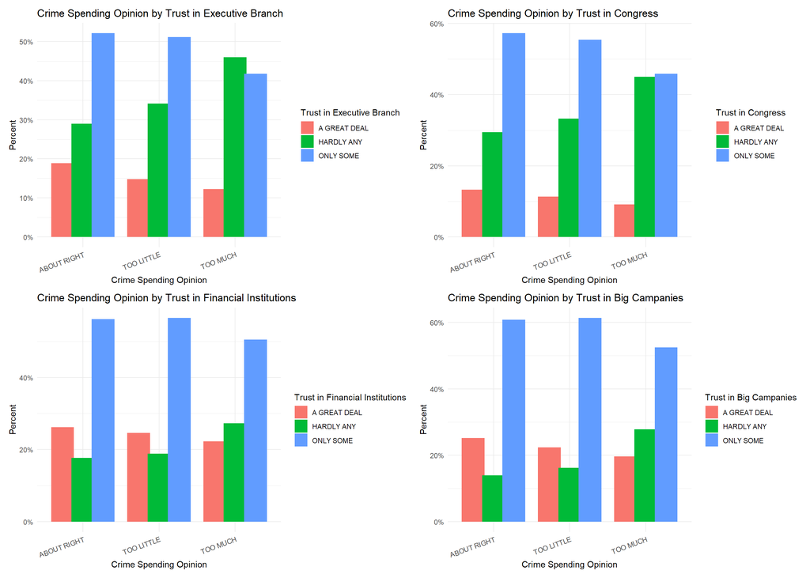

```r
p_confed + p_conlegis + p_confinan + p_conbus
```

### Interpretation

Both the statistical test and the visualization clearly demonstrate that public trust in institutions is strongly related to opinions on crime-control spending. People who lack confidence in institutions tend to believe that the government is not doing enough to address crime, while those who express higher trust are more satisfied with current spending levels.

This provides the first half of the answer to your research question. The next step is to evaluate whether these public perceptions align with actual national crime rates, which we do in the following section.

## Relationship Between National Crime Trends and Public Support for Crime Spending

To evaluate whether public support for increased crime-control spending is associated with actual national crime levels, annual violent-crime totals from the UCR datasets were aggregated and merged with yearly GSS estimates of public attitudes toward crime spending. Because the General Social Survey includes a categorical question (natcrime) asking whether the government spends “TOO LITTLE,” “ABOUT RIGHT,” or “TOO MUCH” on halting rising crime rates, we focused on the proportion of respondents selecting “TOO LITTLE” as an indicator of public demand for increased government intervention.

The violent-crime data were processed by first aggregating monthly records into offense-level annual totals:

```r
crime_yearly <- crime_all %>%
  group_by(offense, year) %>%
  summarise(
    yearly_count = sum(count, na.rm = TRUE),
    yearly_clearances = sum(clearances, na.rm = TRUE),
    .groups = "drop"
  )

crime_total_yearly <- crime_yearly %>%
  group_by(year) %>%
  summarise(
    total_violent_crime = sum(yearly_count),
    total_violent_clearances = sum(yearly_clearances),
    .groups = "drop"
  )
```

The GSS data were then summarized to compute the annual share of respondents indicating that crime spending is “TOO LITTLE”:

```r
gss_crime_support <- GSS_clean %>%
  drop_na(natcrime, year) %>%
  group_by(year) %>%
  summarise(
    prop_too_little = mean(natcrime == "TOO LITTLE"),
    n = n(),
    .groups = "drop"
  ) %>%
  mutate(year = as.numeric(year))
```

After ensuring consistent year variables across datasets, the two sources were merged:

```r
crime_total_yearly <- crime_total_yearly %>%
  mutate(year = as.numeric(year))

merged_crime_gss <- gss_crime_support %>%
  inner_join(crime_total_yearly, by = "year")
```

Two time-series visualizations were then generated to illustrate long-term trends in public opinion and national crime:

```r
p1 <- ggplot(merged_crime_gss, aes(x = year, y = prop_too_little * 100)) +
  geom_line(size = 1.2, color = "steelblue") +
  labs(
    title = "Public Support for Increased Crime Spending",
    x = "Year",
    y = "Percent Saying 'Too Little'"
  ) +
  theme_minimal()
p2 <- ggplot(crime_total_yearly, aes(x = year, y = total_violent_crime)) +
  geom_line(size = 1.2, color = "firebrick") +
  labs(
    title = "Total Violent Crime in the U.S.",
    x = "Year",
    y = "Total Reported Violent Crimes"
  ) +
  theme_minimal()
```

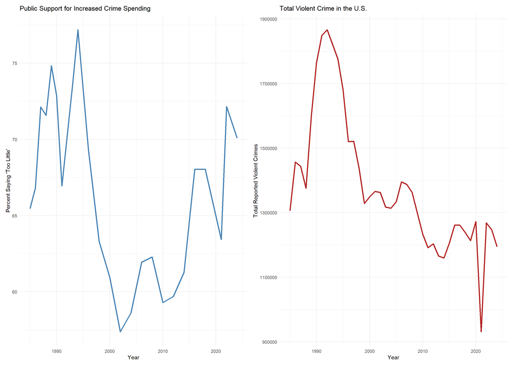

```r
p1 + p2
```

The combined plots show two notable patterns. Public support for increasing crime spending peaked during the early 1990s, declined substantially through the early 2000s, and then rose sharply again in the 2010s. Total violent-crime levels follow a similar pattern, with exceptionally high crime rates around the early 1990s, a long period of decline, and increased volatility in more recent years. These visual parallels suggest a meaningful relationship between actual crime conditions and public sentiment.

To quantify this relationship, Pearson and Spearman correlation coefficients were calculated:

```r
cor(merged_crime_gss$prop_too_little,
    merged_crime_gss$total_violent_crime,
    use = "complete.obs")
```

```
## [1] 0.5507959
```

```r
cor(merged_crime_gss$prop_too_little,
    merged_crime_gss$total_violent_crime,
    method = "spearman",
    use = "complete.obs")
```

```
## [1] 0.5008696
```

Finally, a simple linear regression was fitted to formally assess the predictive relationship:

```r
model <- lm(prop_too_little ~ total_violent_crime, data = merged_crime_gss)
summary(model)
```

```
##
## Call:
## lm(formula = prop_too_little ~ total_violent_crime, data = merged_crime_gss)
##
## Residuals:
##       Min        1Q    Median        3Q       Max
## -0.086446 -0.042214  0.006799  0.040578  0.074396
##
## Coefficients:
##                      Estimate Std. Error t value Pr(>|t|)
## (Intercept)         4.711e-01  6.358e-02   7.410 2.05e-07 ***
## total_violent_crime 1.387e-07  4.482e-08   3.095  0.00528 **
## ---
## Signif. codes:  0 '***' 0.001 '**' 0.01 '*' 0.05 '.' 0.1 ' ' 1
##
## Residual standard error: 0.04878 on 22 degrees of freedom
## Multiple R-squared:  0.3034, Adjusted R-squared:  0.2717
## F-statistic: 9.581 on 1 and 22 DF,  p-value: 0.005283
```

The regression results indicate that violent-crime totals significantly predict public demand for more crime spending (p = 0.00528). The positive coefficient shows that as national violent-crime levels rise, so does the share of respondents calling for more government spending. The model explains roughly 30 percent of the year-to-year variation in public opinion (R² = 0.3034), suggesting that crime rates are an important, though not exclusive, factor shaping public perceptions.

Overall, the statistical evidence demonstrates that public approval for increased crime-control spending is meaningfully and positively associated with national violent-crime trends. Americans tend to demand greater government action when actual crime levels are high or increasing, indicating that public opinion in this area is responsive to real-world conditions rather than being solely driven by political or media rhetoric.